# project

Anonymous

11/14/2020

# Loaded packages

```r
library(rstan)
rstan_options(auto_write = TRUE)
options(mc.cores = 1)
library(ggplot2)
library(aaltobda)
library(shinystan)
library(bayesplot)
library(loo)
library(dlookr)
library(corrplot)
SEED <- 48927
```

# Data

## Option 1. Heart Disease dataset

```r
heart_data = read.csv('heartdisease.csv')
names(heart_data) <- c('age', 'sex', 'chest_pain_type', 'resting_blood_pressure', 'cholesterol', 'fasting_blood_sugar', 'rest_ecg', 'max_heart_rate_achieved',
       'exercise_induced_angina', 'st_depression', 'st_slope', 'num_major_vessels', 'thalassemia', 'target')
head(heart_data)
```

```
##   age sex chest_pain_type resting_blood_pressure cholesterol
## 1  63   1               3                    145         233
## 2  37   1               2                    130         250
## 3  41   0               1                    130         204
## 4  56   1               1                    120         236
## 5  57   0               0                    120         354
## 6  57   1               0                    140         192
##   fasting_blood_sugar rest_ecg max_heart_rate_achieved exercise_induced_angina
## 1                   1        0                     150                       0
## 2                   0        1                     187                       0
## 3                   0        0                     172                       0
## 4                   0        1                     178                       0
## 5                   0        1                     163                       1
## 6                   0        1                     148                       0
##   st_depression st_slope num_major_vessels thalassemia target
## 1           2.3        0                 0           1      1
## 2           3.5        0                 0           2      1
## 3           1.4        2                 0           2      1
## 4           0.8        2                 0           2      1
## 5           0.6        2                 0           2      1
## 6           0.4        1                 0           1      1
```

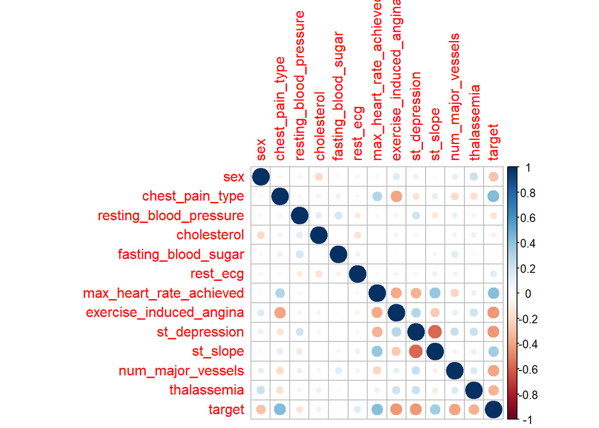

```r
corrplot(cor(heart_data[,2:14]))
```

```r
describe(heart_data)
```

```
## # A tibble: 14 x 26
##    variable     n    na    mean     sd se_mean   IQR skewness kurtosis   p00
##    <chr>    <int> <int>   <dbl>  <dbl>   <dbl> <dbl>    <dbl>    <dbl> <dbl>
##  1 age        303     0  54.4    9.08   0.522   13.5   -0.202  -0.542     29
##  2 sex        303     0   0.683  0.466  0.0268   1     -0.791  -1.38       0
##  3 chest_p~   303     0   0.967  1.03   0.0593   2      0.485  -1.19       0
##  4 resting~   303     0 132.    17.5    1.01    20      0.714   0.929     94
##  5 cholest~   303     0 246.    51.8    2.98    63.5    1.14    4.51     126
##  6 fasting~   303     0   0.149  0.356  0.0205   0      1.99    1.96       0
##  7 rest_ecg   303     0   0.528  0.526  0.0302   1      0.163  -1.36       0
##  8 max_hea~   303     0 150.    22.9    1.32    32.5   -0.537  -0.0620    71
##  9 exercis~   303     0   0.327  0.470  0.0270   1      0.743  -1.46       0
## 10 st_depr~   303     0   1.04   1.16   0.0667   1.6    1.27    1.58       0
## 11 st_slope   303     0   1.40   0.616  0.0354   1     -0.508  -0.628      0
## 12 num_maj~   303     0   0.729  1.02   0.0587   1      1.31    0.839      0
## 13 thalass~   303     0   2.31   0.612  0.0352   1     -0.477   0.298      0
## 14 target     303     0   0.545  0.499  0.0287   1     -0.180  -1.98       0
## # ... with 16 more variables: p01 <dbl>, p05 <dbl>, p10 <dbl>, p20 <dbl>,
## #   p25 <dbl>, p30 <dbl>, p40 <dbl>, p50 <dbl>, p60 <dbl>, p70 <dbl>,
## #   p75 <dbl>, p80 <dbl>, p90 <dbl>, p95 <dbl>, p99 <dbl>, p100 <dbl>
```

## Option 2. Breast cancer dataset

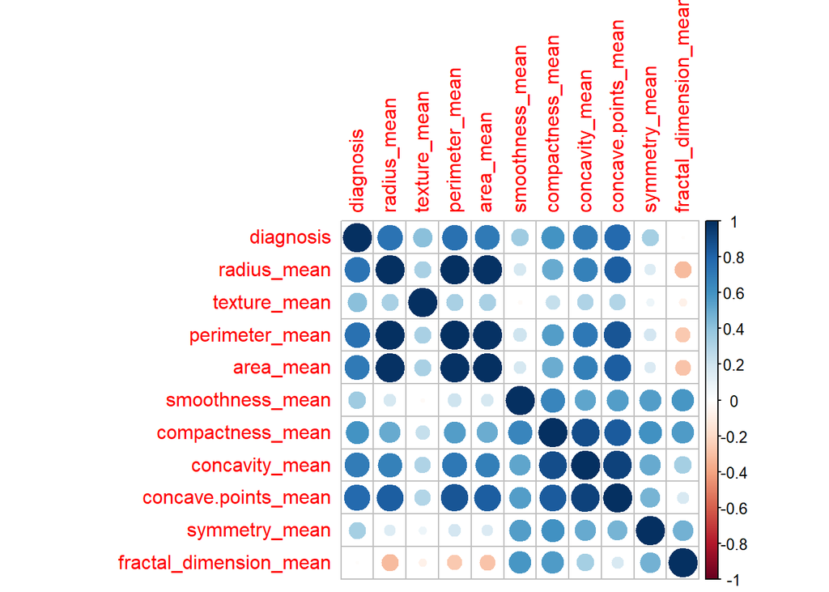

```r
cancer_data = read.csv('cancer.csv')
cancer_data[cancer_data == "B"] <- as.numeric(0)
cancer_data[cancer_data == "M"] <- as.numeric(1)
cancer_data$diagnosis <- as.numeric(as.character(cancer_data$diagnosis))
corrplot(cor(cancer_data[,2:12]))
```

```r
describe(cancer_data)
```

```
## # A tibble: 32 x 26
##    variable     n    na    mean      sd se_mean     IQR skewness kurtosis
##    <chr>    <int> <int>   <dbl>   <dbl>   <dbl>   <dbl>    <dbl>    <dbl>
##  1 id         569     0 3.04e+7 1.25e+8 5.24e+6 7.94e+6    6.47    42.2
##  2 diagnos~   569     0 3.73e-1 4.84e-1 2.03e-2 1.00e+0    0.528   -1.73
##  3 radius_~   569     0 1.41e+1 3.52e+0 1.48e-1 4.08e+0    0.942    0.846
##  4 texture~   569     0 1.93e+1 4.30e+0 1.80e-1 5.63e+0    0.650    0.758
##  5 perimet~   569     0 9.20e+1 2.43e+1 1.02e+0 2.89e+1    0.991    0.972
##  6 area_me~   569     0 6.55e+2 3.52e+2 1.48e+1 3.62e+2    1.65     3.65
##  7 smoothn~   569     0 9.64e-2 1.41e-2 5.90e-4 1.89e-2    0.456    0.856
##  8 compact~   569     0 1.04e-1 5.28e-2 2.21e-3 6.55e-2    1.19     1.65
##  9 concavi~   569     0 8.88e-2 7.97e-2 3.34e-3 1.01e-1    1.40     2.00
## 10 concave~   569     0 4.89e-2 3.88e-2 1.63e-3 5.37e-2    1.17     1.07
## # ... with 22 more rows, and 17 more variables: p00 <dbl>, p01 <dbl>,
## #   p05 <dbl>, p10 <dbl>, p20 <dbl>, p25 <dbl>, p30 <dbl>, p40 <dbl>,
## #   p50 <dbl>, p60 <dbl>, p70 <dbl>, p75 <dbl>, p80 <dbl>, p90 <dbl>,
## #   p95 <dbl>, p99 <dbl>, p100 <dbl>
```

```r
head(cancer_data)
```

```
##         id diagnosis radius_mean texture_mean perimeter_mean area_mean
## 1   842302         1       17.99        10.38         122.80    1001.0
## 2   842517         1       20.57        17.77         132.90    1326.0
## 3 84300903         1       19.69        21.25         130.00    1203.0
## 4 84348301         1       11.42        20.38          77.58     386.1
## 5 84358402         1       20.29        14.34         135.10    1297.0
## 6   843786         1       12.45        15.70          82.57     477.1
##   smoothness_mean compactness_mean concavity_mean concave.points_mean
## 1         0.11840          0.27760         0.3001             0.14710
## 2         0.08474          0.07864         0.0869             0.07017
## 3         0.10960          0.15990         0.1974             0.12790
## 4         0.14250          0.28390         0.2414             0.10520
## 5         0.10030          0.13280         0.1980             0.10430
## 6         0.12780          0.17000         0.1578             0.08089
##   symmetry_mean fractal_dimension_mean radius_se texture_se perimeter_se
```

[output cut: 34 more lines]

# Preprocessing

## Feature selection

For this task, we reduce the number of input variables in order to develop our models. As seen in the correlation map, variables such as **radius_mean**, **perimeter_mean** and **area_mean** are highly correlated. Thus, we discard the variables **radius_mean**, **perimeter_mean**. Etc…

```r
cancer_data$radius_mean <- NULL
cancer_data$perimeter_mean <- NULL
cancer_data$compactness_mean <- NULL
cancer_data$concave.points_mean <- NULL
cancer_data$radius_se <- NULL
cancer_data$perimeter_se <- NULL
cancer_data$compactness_se <- NULL
cancer_data$concave.points_se <- NULL
cancer_data$radius_worst <- NULL
cancer_data$perimeter_worst <- NULL
cancer_data$compactness_worst <- NULL
cancer_data$concave.points_worst <- NULL
cancer_data$X <- NULL
cancer_data$area_worst <- NULL
cancer_data$texture_worst <- NULL
```

### Selected variables

```r
head(cancer_data)
```

```
##         id diagnosis texture_mean area_mean smoothness_mean concavity_mean
## 1   842302         1        10.38    1001.0         0.11840         0.3001
## 2   842517         1        17.77    1326.0         0.08474         0.0869
## 3 84300903         1        21.25    1203.0         0.10960         0.1974
## 4 84348301         1        20.38     386.1         0.14250         0.2414
## 5 84358402         1        14.34    1297.0         0.10030         0.1980
## 6   843786         1        15.70     477.1         0.12780         0.1578
##   symmetry_mean fractal_dimension_mean texture_se area_se smoothness_se
## 1        0.2419                0.07871     0.9053  153.40      0.006399
## 2        0.1812                0.05667     0.7339   74.08      0.005225
## 3        0.2069                0.05999     0.7869   94.03      0.006150
## 4        0.2597                0.09744     1.1560   27.23      0.009110
## 5        0.1809                0.05883     0.7813   94.44      0.011490
## 6        0.2087                0.07613     0.8902   27.19      0.007510
##   concavity_se symmetry_se fractal_dimension_se smoothness_worst
## 1      0.05373     0.03003             0.006193           0.1622
## 2      0.01860     0.01389             0.003532           0.1238
## 3      0.03832     0.02250             0.004571           0.1444
## 4      0.05661     0.05963             0.009208           0.2098
## 5      0.05688     0.01756             0.005115           0.1374
## 6      0.03672     0.02165             0.005082           0.1791
##   concavity_worst symmetry_worst fractal_dimension_worst
## 1          0.7119         0.4601                 0.11890
## 2          0.2416         0.2750                 0.08902
## 3          0.4504         0.3613                 0.08758
## 4          0.6869         0.6638                 0.17300
## 5          0.4000         0.2364                 0.07678
## 6          0.5355         0.3985                 0.12440
```

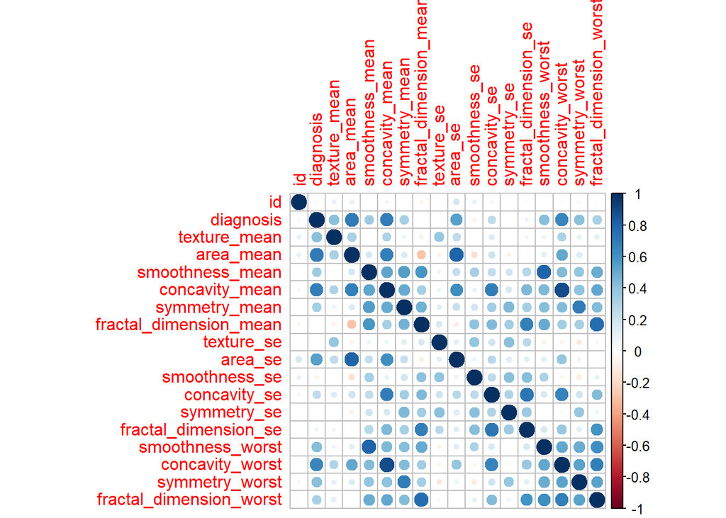

```r
corrplot(cor(cancer_data))
```

```r
#hist(cancer_data$texture_mean)
#hist(cancer_data$area_mean)
#hist(cancer_data$smoothness_mean)
#hist(cancer_data$symmetry_mean)
#hist(cancer_data$texture_se)
```

## Scaling

```r
scaled_cancer_data <- cancer_data
col_names <- colnames(cancer_data)

scaled_cancer_data[,1:2] <- cancer_data[,1:2]
scaled_cancer_data[,3:18] <- scale(cancer_data[,3:18])
colnames(scaled_cancer_data) <- col_names
head(scaled_cancer_data)
```

```
##         id diagnosis texture_mean  area_mean smoothness_mean concavity_mean
## 1   842302         1   -2.0715123  0.9835095       1.5670875     2.65054179
## 2   842517         1   -0.3533215  1.9070303      -0.8262354    -0.02382489
## 3 84300903         1    0.4557859  1.5575132       0.9413821     1.36227979
## 4 84348301         1    0.2535091 -0.7637917       3.2806668     1.91421287
## 5 84358402         1   -1.1508038  1.8246238       0.2801253     1.36980615
## 6   843786         1   -0.8346009 -0.5052059       2.2354545     0.86554001
##   symmetry_mean fractal_dimension_mean texture_se    area_se smoothness_se
## 1   2.215565542              2.2537638 -0.5647681  2.4853907    -0.2138135
## 2   0.001391139             -0.8678888 -0.8754733  0.7417493    -0.6048187
## 3   0.938858720             -0.3976580 -0.7793976  1.1802975    -0.2967439
## 4   2.864862154              4.9066020 -0.1103120 -0.2881246     0.6890953
## 5  -0.009552062             -0.5619555 -0.7895490  1.1893103     1.4817634
## 6   1.004517928              1.8883435 -0.5921406 -0.2890039     0.1562093
##   concavity_se symmetry_se fractal_dimension_se smoothness_worst
## 1    0.7233897   1.1477468           0.90628565        1.3065367
## 2   -0.4403926  -0.8047423          -0.09935632       -0.3752817
## 3    0.2128891   0.2368272           0.29330133        0.5269438
## 4    0.8187979   4.7285198           2.04571087        3.3912907
## 5    0.8277425  -0.3607748           0.49888916        0.2203623
## 6    0.1598845   0.1340009           0.48641784        2.0467119
##   concavity_worst symmetry_worst fractal_dimension_worst
## 1       2.1076718      2.7482041               1.9353117
## 2      -0.1466200     -0.2436753               0.2809428
## 3       0.8542223      1.1512420               0.2012142
## 4       1.9878392      6.0407261               4.9306719
## 5       0.6126397     -0.8675896              -0.3967505
## 6       1.2621327      1.7525273               2.2398308
```

# Model definitions

```r
model_data <- list(N=length(scaled_cancer_data$diagnosis), y=c(scaled_cancer_data$diagnosis), x=c(scaled_cancer_data$area_mean))
model_stan <- rstan::stan_model(file = "models/model1.stan")
model_sampling <- rstan::sampling(model_stan, data = model_data, refresh=0, seed=SEED)
```

```r
monitor(model_sampling)
```

```
## Inference for the input samples (4 chains: each with iter = 2000; warmup = 0):
##
##                 Q5   Q50   Q95  Mean  SD  Rhat Bulk_ESS Tail_ESS
## alpha          0.4   0.4   0.4   0.4 0.0     1     4391     3141
## beta           0.3   0.3   0.4   0.3 0.0     1     4195     3165
## sigma          0.3   0.3   0.4   0.3 0.0     1     3862     3001
## log_lik[1]    -0.3  -0.2  -0.1  -0.2 0.0     1     4375     3318
## log_lik[2]     0.1   0.1   0.2   0.1 0.0     1     3724     3178
## log_lik[3]     0.1   0.1   0.2   0.1 0.0     1     3957     3112
## log_lik[4]    -3.6  -3.2  -2.9  -3.2 0.2     1     4140     3158
## log_lik[5]     0.1   0.2   0.2   0.1 0.0     1     3704     3144
## log_lik[6]    -2.9  -2.6  -2.3  -2.6 0.2     1     4195     3081
## log_lik[7]    -0.2  -0.1   0.0  -0.1 0.0     1     4323     3324
## log_lik[8]    -2.2  -2.0  -1.8  -2.0 0.1     1     4251     2938
## log_lik[9]    -2.6  -2.3  -2.1  -2.3 0.1     1     4213     3057
## log_lik[10]   -2.9  -2.6  -2.3  -2.6 0.2     1     4194     3081
## log_lik[11]   -1.0  -0.9  -0.8  -0.9 0.1     1     4317     3074
## log_lik[12]   -1.1  -0.9  -0.8  -0.9 0.1     1     4298     3016
## log_lik[13]    0.0   0.0   0.1   0.0 0.0     1     4173     3244
## log_lik[14]   -1.0  -0.9  -0.8  -0.9 0.1     1     4300     3040
## log_lik[15]   -2.2  -1.9  -1.7  -2.0 0.1     1     4252     2916
## log_lik[16]   -1.7  -1.5  -1.4  -1.5 0.1     1     4203     2885
## log_lik[17]   -1.5  -1.4  -1.2  -1.4 0.1     1     4217     2894
## log_lik[18]   -1.0  -0.9  -0.8  -0.9 0.1     1     4319     3074
## log_lik[19]    0.1   0.1   0.2   0.1 0.0     1     3774     2969
## log_lik[20]   -0.3  -0.2  -0.1  -0.2 0.0     1     4313     3007
## log_lik[21]   -0.2  -0.1   0.0  -0.1 0.0     1     4252     3029
## log_lik[22]    0.1   0.2   0.2   0.2 0.0     1     3800     3054
## log_lik[23]   -1.4  -1.3  -1.1  -1.3 0.1     1     4232     2907
## log_lik[24]    0.0   0.1   0.2   0.1 0.0     1     4026     2786
## log_lik[25]   -0.6  -0.5  -0.4  -0.5 0.1     1     4405     3044
## log_lik[26]   -0.5  -0.5  -0.4  -0.5 0.1     1     4408     3120
## log_lik[27]   -1.8  -1.6  -1.4  -1.6 0.1     1     4196     2872
## log_lik[28]   -0.1   0.0   0.1   0.0 0.0     1     4217     3238
## log_lik[29]   -1.3  -1.1  -1.0  -1.1 0.1     1     4253     3013
## log_lik[30]   -0.4  -0.3  -0.2  -0.3 0.1     1     4433     3172
## log_lik[31]   -0.1   0.0   0.0   0.0 0.0     1     4232     3210
## log_lik[32]   -3.2  -2.8  -2.5  -2.8 0.2     1     4179     3185
## log_lik[33]   -0.6  -0.5  -0.4  -0.5 0.1     1     4403     3021
## log_lik[34]    0.0   0.1   0.1   0.1 0.0     1     4082     3139
```

[output cut: 526 more lines]

```
## log_lik[561]  -0.3  -0.3  -0.2  -0.3 0.0     1     4355     2818
## log_lik[562]   0.0   0.1   0.2   0.1 0.0     1     3863     3184
## log_lik[563]  -1.4  -1.2  -1.1  -1.2 0.1     1     4241     2908
## log_lik[564]   0.1   0.1   0.2   0.1 0.0     1     3777     2595
## log_lik[565]  -0.1   0.0   0.1   0.0 0.1     1     4245     2837
## log_lik[566]   0.1   0.1   0.2   0.1 0.0     1     3770     2969
## log_lik[567]  -0.7  -0.6  -0.5  -0.6 0.1     1     4382     3188
## log_lik[568]   0.1   0.1   0.2   0.1 0.0     1     3761     2969
## log_lik[569]   0.1   0.1   0.2   0.1 0.0     1     3930     2987
## lp__         322.8 325.5 326.5 325.2 1.2     1     2133     2692
##
## For each parameter, Bulk_ESS and Tail_ESS are crude measures of
## effective sample size for bulk and tail quantities respectively (an ESS > 100
## per chain is considered good), and Rhat is the potential scale reduction
## factor on rank normalized split chains (at convergence, Rhat <= 1.05).
```

```r
model_log_lik <- extract_log_lik(model_sampling, parameter_name = "log_lik", merge_chains = FALSE)
model_r_eff <- relative_eff(exp(model_log_lik), cores = 2)
model_loo <- loo(model_log_lik, r_eff = model_r_eff, cores = 2)

pooled_k_values <- model_loo$diagnostics$pareto_k
print(model_loo$diagnostics)
```

[output not shown]

[output cut: 174 more lines]

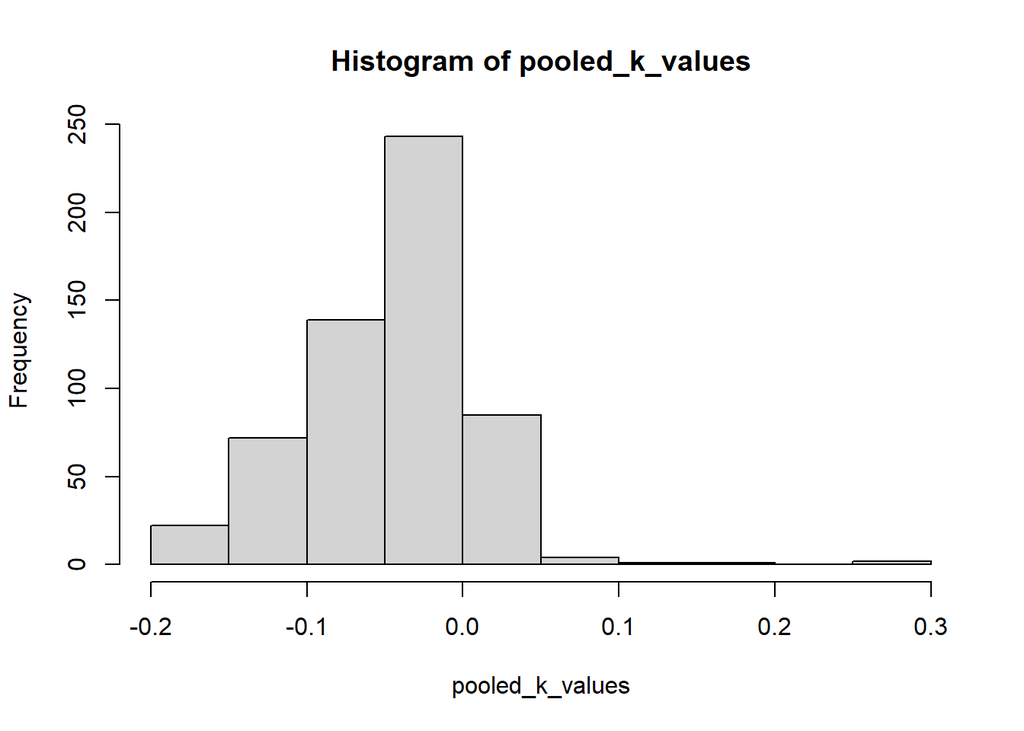

```r
hist(pooled_k_values)
```

# Convergence diagnostics

$\hat{R}$ can be used to monitor if a group of chains has converged to the target distribution. This can be done by comparing the between and within-chain estimate for model parameters. If chains have not converged, meaning that they have not mixed well, $\hat{R}$ will be greater than one. If chains have converged, the $\hat{R}$ value will be virtually one.

## ESS

We would like to have a diagnostic that tell us when the weights are problematic, as we could have vastly imbalanced weights. In this case, we could use **effective sample size ($S_{eff}$)**, a quantitative measure of efficiency in **importance sampling**. $S_{eff}$ represents the number of independent samples required to obtain an importance sampling estimate with about the same efficiency as if we would have used all the samples.

`monitor` function gives us two crude measures of effective sample size called Bulk_ESS and Tail_ESS (an $ESS > 100$ per chain is considered good). As seen in the `monitor` outputs, our ESS values are way higher than 100, which established that our values are good. (Aún no está claro que esto sea válido, preguntar a TA)

## Divergences

A divergence arises when the simulated Hamiltonian trajectory departs from the true trajectory as measured by departure of the Hamiltonian value from its initial value […]. Habrá que indicar si hemos obtenido divergencias o no en los modelos más adelante con la siguiente función:

```r
check_hmc_diagnostics(model_sampling)
```

```
##
## Divergences:
```

```
## 0 of 4000 iterations ended with a divergence.
```

```
##
## Tree depth:
```

```
## 0 of 4000 iterations saturated the maximum tree depth of 10.
```

```
##
## Energy:
```

```
## E-BFMI indicated no pathological behavior.
```